# R Notebook

Daniel Peña

```r
library(ggplot2)
library(deSolve)
library(tidyverse)
```

## DATA

I downlowaded the date from RamiKrispin’s Github https://github.com/RamiKrispin/coronavirus/blob/master/data/coronavirus.rda

## Managing DATA

In order to be able to use this data for our model, I added all the data points so that we had a number of total cases for each given day. I took out Feb-13, because it added more cases due to new identification tecniques. I am yet to try the model with this info.

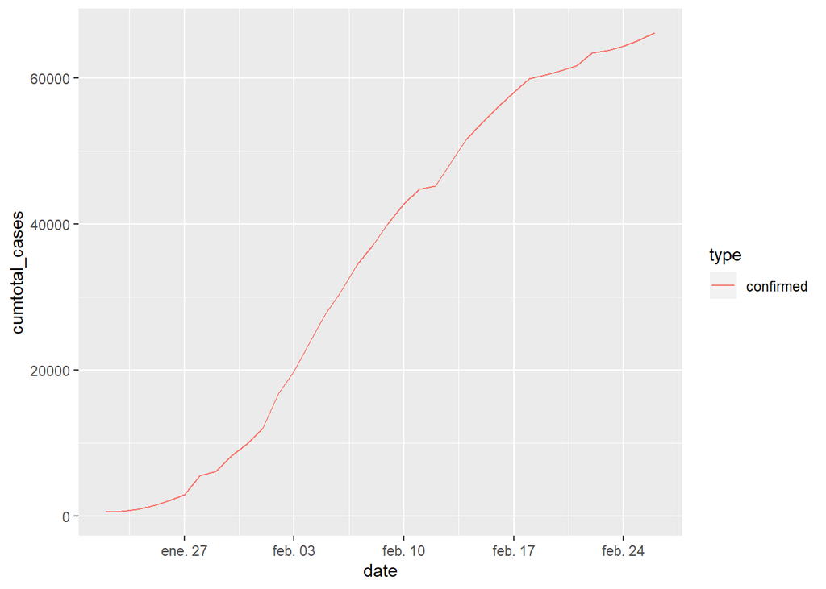

```r
c1 <- coronavirus %>%
  select(date,type,cases) %>%
  group_by(date,type) %>%
  summarise(total_cases = sum(cases))

c2 <- c1[which(c1$type=="confirmed" & c1$date != "2020-02-13"   ),]

c2$cumtotal_cases <- cumsum(c2$total_cases)

ggplot(data= c2 ,aes(date,cumtotal_cases, colour = type)) + geom_line()
```

## Model

I set the population = 50,000,000 which is a good estimate. Also I create a vector Infected which takes in the info from the coronavirus data.

This model is adapted from Learning Machine’s post https://blog.ephorie.de/epidemiology-how-contagious-is-novel-coronavirus-2019-ncov

```r
pop <-50000000

Infected <- as.integer(c2$cumtotal_cases)

Dia <- 1:length(Infected)

old <- par(mfrow = c(1, 2))

SIR <- function(time, state, parameters) {
  par <- as.list(c(state, parameters))
  with(par, {
    dS <- -beta/pop * I * S
    dI <- beta/pop * I * S - gamma * I
    dR <- gamma * I
    list(c(dS, dI, dR))
    })
}
```

## Sum of Squared Differences

RSS takes the info given and minimizes the Sum of Squared Differences, between the number of infected I at time t and the corresponding number of predicted cases by our model ^{I}(t)

$$RSS(\beta, \gamma) = \sum_{t} \left( I(t)-{I}(t) \right)^2$$

```r
init <- c(S = pop-Infected[1], I = Infected[1], R = 0)
RSS <- function(parameters) {
  names(parameters) <- c("beta", "gamma")
  out <- ode(y = init, times = Dia, func = SIR, parms = parameters)
  fit <- out[ , 3]
  sum((Infected - fit)^2)
}

Opt <- optim(c(0.5, 0.5), RSS, method = "L-BFGS-B", lower = c(0, 0), upper = c(1, 1)) # optimize with some sensible conditions

Opt_par <- setNames(Opt$par, c("beta", "gamma"))
Opt_par
```

```
##      beta     gamma
## 0.5770345 0.4229655
```

```r
t <- 1:100 # time in days
fit <- data.frame(ode(y = init, times = t, func = SIR, parms = Opt_par))
```

## Interesting Stats

In learning machine’s post R0 is calculated at 2.073224, we have a much lower value at 1.364, this R0 refers to the number of healthy people that get infected per number of infected people. I believe it is much lower because the DATA that I am using here shows a far slower expansion, also maybe the population difference might affect this indicator, although I think it is unlikely.

```r
par(old)

R0 <- setNames(Opt_par["beta"] / Opt_par["gamma"], "R0")

Height <- fit[fit$I == max(fit$I), "I", drop = FALSE] # height of pandemic

Max_Dead <- max(fit$I) * 0.02 # max deaths with supposed 2% mortality rate

R0
```

```
##       R0
## 1.364259
```

```r
Height
```

|  | I |
| --- | --- |
| 64 | 1966588 |

```r
Max_Dead
```

```
## [1] 39331.75
```

## Graphs

I like nice graphs, the code is long, so I will just leave the first one.

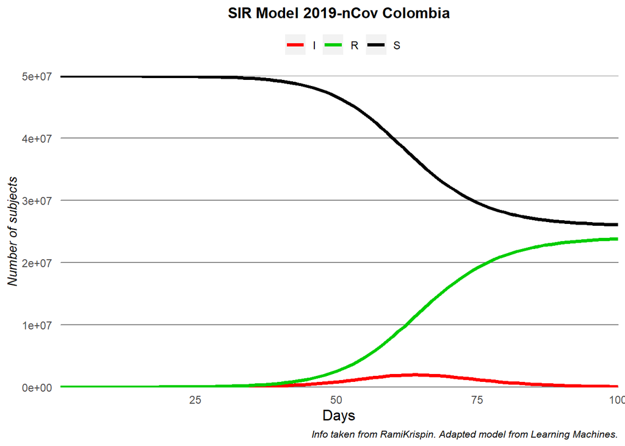

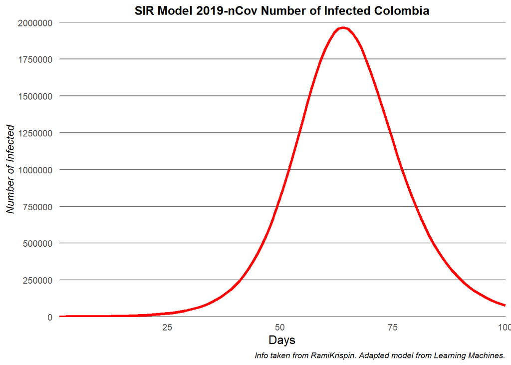

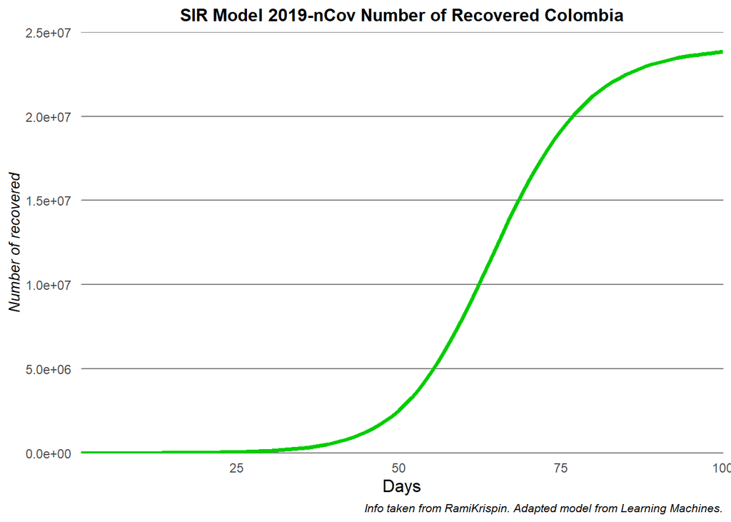

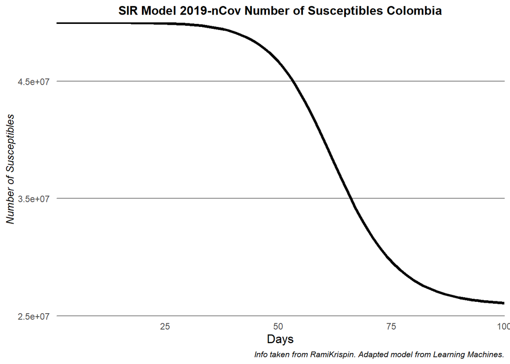

```r
graph11 <- fit %>% gather(key, value, -time)

bigplot <- ggplot(graph11, mapping = aes(x = time, y = value, color = key) ) +
  geom_line(size =1.25)+
  scale_color_manual( values =
    c("red1", "green3","gray1"))+

  theme(
    plot.title = element_text(size = 12, face = "bold",hjust = 0.5),
    plot.caption = element_text(size = 8, face = "italic"),
    legend.position="top",
    legend.title = element_blank(),
    legend.box = "horizontal" ,
    legend.text=element_text(size=8.5),
    panel.grid.minor = element_blank(),
    panel.grid.major = element_line(color = "gray50", size = 0.5),
    panel.grid.major.x = element_blank(),
    panel.background = element_blank(),
    line = element_blank(),
    axis.ticks.length = unit(.15, "cm"),
    axis.ticks.y = element_blank(),
    axis.title.x = element_text(color="black",
    size=12),
    axis.title.y = element_text(color="black",
    size=10,
    face="italic"))+

  scale_y_continuous(expand = c(0, 0),
    limits=c(0.0,50000000),
    breaks=seq(0.0,50000000,10000000),
    name = "Number of subjects")+

  scale_x_continuous(expand = c(0, 0),
    name = "Days")+

  labs(title = "SIR Model 2019-nCov Colombia",
       caption = "Info taken from RamiKrispin. Adapted model from Learning Machines.")

bigplot
```

## Final Thoughts

This model is very simple and there is a huge number of other variables that need to be considered, such as density, climate, governments response … etc. Nevertheless, it was fun to build. Many thanks to RamiKrispin for the data and to Learning Machine for the tutorial.